# Analysis on Cyclistic Data

### Total Users By Days

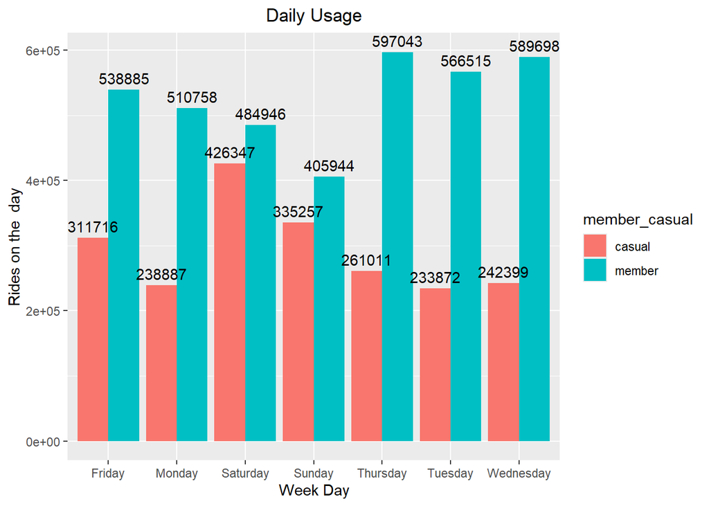

```r
a %>% group_by(member_casual,start_day) %>%
  summarise(total_users = n()) %>%
  ggplot(aes(x = start_day,y= total_users, fill = member_casual)) +
  geom_col(position = "dodge") + labs(x = "Week Day",
  y ="Rides on the  day", title ="Daily Usage") +  geom_text(aes(
  label = total_users),
  position = position_dodge(width = 0.9) , vjust = -0.5) +
  theme(plot.title = element_text(hjust = 0.5))
```

Members are the leading users of bikes. But during weekends, casuals are also looking for bikes as much as members do.

## Users with usage_time between 45 and 600 minutes

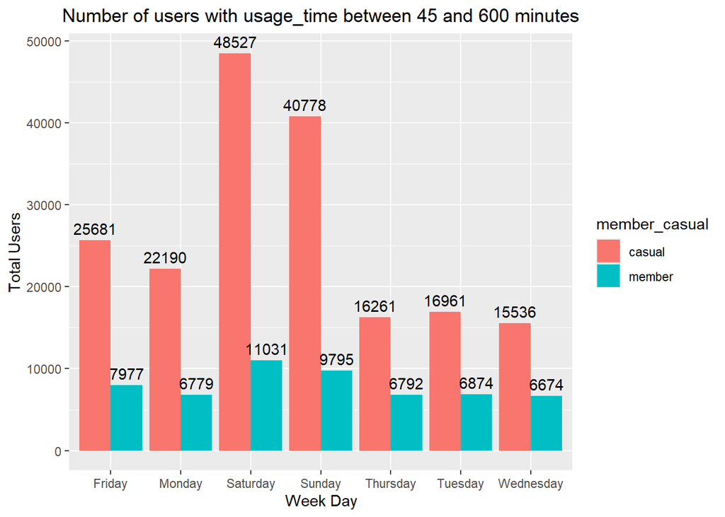

```r
a %>% filter(round(usage_time) > 45 & round(usage_time) < 600) %>%
  group_by(member_casual, start_day) %>%
  summarise(num = n()) %>% ggplot(aes(x=start_day, y=num,
  fill = member_casual )) + geom_col(position = "dodge") +
  geom_text(aes(label = num), position = position_dodge(width = 0.9)
  , vjust = -0.5) + labs(x = "Week Day", y ="Total Users",
  title ="Number of users with usage_time between 45 and 600 minutes") +   theme(plot.title = element_text(hjust = 0.5))
```

It’s clear that, casuals are using bikes in higher range with an usage_time between 45 and 600 minutes. New membership schemes can be implemented based on hours.

### Usage Hour

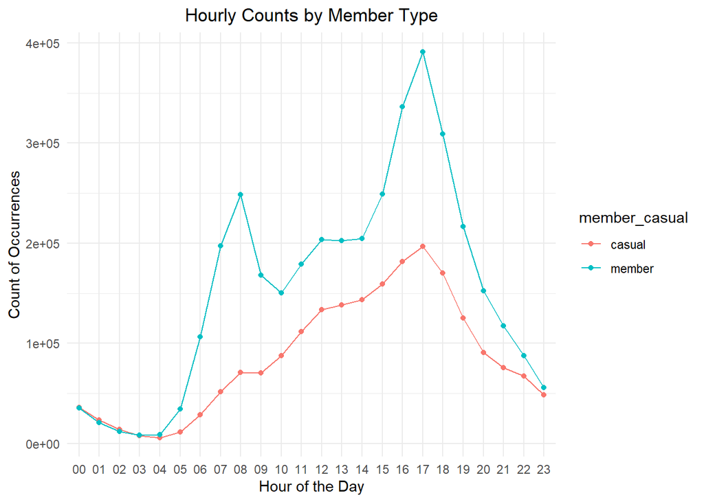

```r
a %>% mutate(start_time = as.POSIXct(start_time, format="%Y-%m-%d %H:%M:%S"),
hour = format(start_time, "%H")) %>% group_by(member_casual,hour) %>%
summarise( count = n()) %>% ggplot( aes(x = hour, y = count, group = member_casual, color = member_casual)) +geom_line() +geom_point() +
labs(title = "Hourly Counts by Member Type",x = "Hour of the Day",
y = "Count of Occurrences") + theme_minimal() +
theme(plot.title = element_text(hjust = 0.5))
```

People are showing interests to make use of bikes during day time. So, membership scheme based on hours must be a good choice.

## Monthly Users

```r
library(lubridate)
```

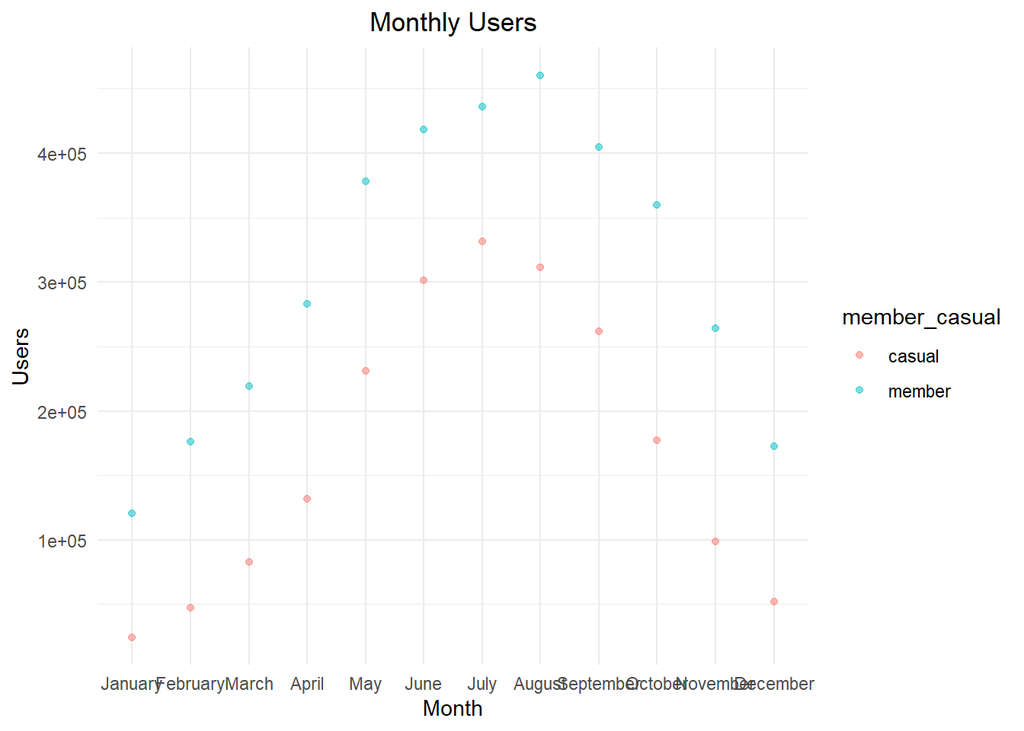

```r
a %>% mutate(mon = month(start_date,label = TRUE, abbr = FALSE)) %>% group_by(member_casual, mon) %>% summarise(total = n(),.groups = 'drop') %>% ggplot(aes(x= mon, y=total,group = member_casual, color = member_casual)) + geom_point(alpha = 0.5) +labs(title = "Monthly Users",x = "Month",y = "Users") +theme_minimal() +
theme(plot.title = element_text(hjust = 0.5))
```

The numbers highly vary among months. So, monthly memberships will play a vital role in attracting casual riders.